**Artificial Neural Networks (ANN)**

Table of Contents

# 1. Recall Perceptron

This notebook builds the artificial neural network from a single component that is already familiar. Before adding anything new, it is worth restating precisely what a perceptron is and precisely where it fails, because the entire architecture developed in this chapter is a response to that one failure.

The plan of the notebook is as follows. Chapter 1 recalls the perceptron and its limitation. Chapter 2 shows how stacking perceptrons removes that limitation, and interprets hidden layers as learned feature extractors. Chapters 3 and 4 examine the internal behavior of a trained network on a classification and a regression example. Chapter 5 assembles these observations into a general description of the artificial neural network. Chapter 6 addresses how such a network is trained, arriving at the backpropagation algorithm by way of recursion and dynamic programming. Chapter 7 applies everything to handwritten digit recognition.

```python
from IPython.display import HTML, display

display(HTML(f"""
<iframe
  width="560"
  height="315"
  src="https://www.youtube.com/embed/W5i9OA0bW-A"
  style="border:1px solid black;"
  referrerpolicy="strict-origin-when-cross-origin">
</iframe>
"""))
```

[video not shown]

**Perceptron**

A perceptron models the decision boundary as a linear equation:

$$\omega_0 + \omega_1 x_1 + \omega_2 x_2 + \cdots + \omega_d x_d = 0$$

This means that a perceptron can only create a straight-line (hyperplane) to separate the data. It is instructive to conceptualize a single perceptron as representing a hyperplane in a geometric space.

This identification is worth holding onto, because it is the key to reading everything that follows:

$$ \text{one perceptron} \; = \; \text{one hyperplane} $$

The weights $\omega_1, \cdots, \omega_d$ determine the orientation of that hyperplane and $\omega_0$ determines its offset from the origin. Training a perceptron means moving a single flat surface into position, and nothing a perceptron does can produce a boundary that is not flat.

Once this is accepted, the question that organizes this entire notebook becomes almost obvious. If one perceptron gives one hyperplane, what does a collection of perceptrons give, and what happens when their outputs are fed into further perceptrons?

**XOR Problem**

Minsky-Papert Controversy on XOR

- not linearly separable
- limitation of perceptron

A perceptron is a simple linear classifier that separates data using a single hyperplane. However, there are some classification tasks that a perceptron cannot solve due to its linear nature. A classic example of this limitation is the XOR (exclusive OR) problem.

The XOR function is defined on four points, and its labels can be checked at a glance:

| $x_1$ | $x_2$ | $y$ |
| --- | --- | --- |
| 0 | 0 | 0 |
| 0 | 1 | 1 |
| 1 | 0 | 1 |
| 1 | 1 | 0 |

The two points labelled $1$ occupy one diagonal of the unit square and the two labelled $0$ occupy the other. Any straight line drawn in the plane leaves at least one point on the wrong side, so no choice of $\omega_0, \omega_1, \omega_2$ can classify all four correctly. The perceptron does not fail here because the training algorithm is inadequate; it fails because the model itself cannot express the required boundary.

This is worth emphasizing because it tells us where to look for a remedy. Improving the optimizer, collecting more data, or training for longer cannot help. Only enlarging the family of functions the model can represent can help, and there are exactly two ways to do that.

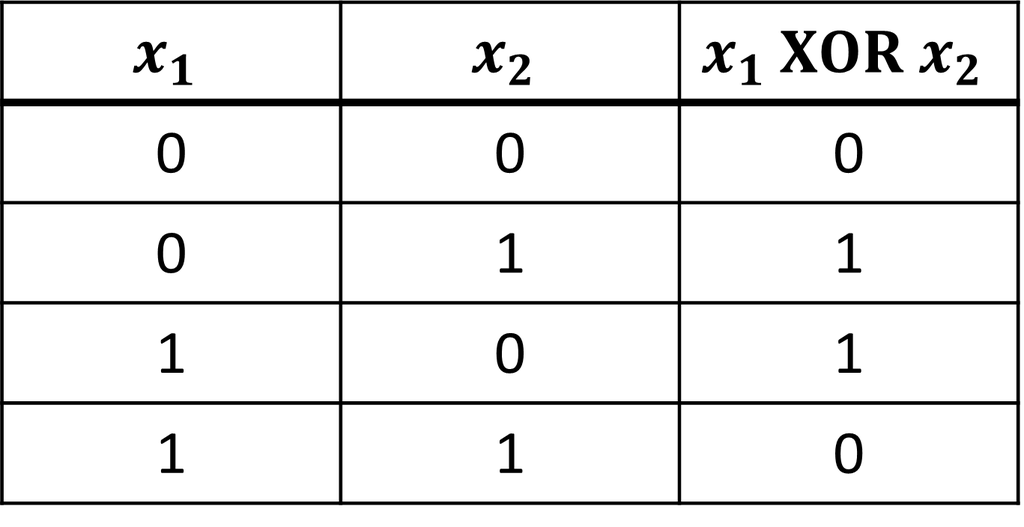

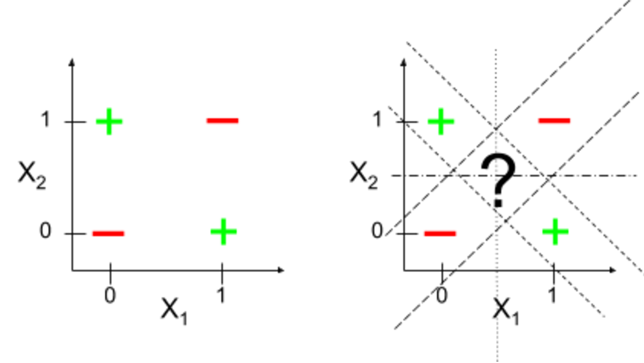

# 2. From Perceptron to Multi-Layer Perceptron (MLP)

To explain the concept of a multi-layer perceptron (MLP), we start with a simple perceptron and establish its connection to a single hyperplane. A perceptron functions as a linear classifier by learning a hyperplane that separates data into distinct classes. However, when the data is non-linearly separable, a single hyperplane is insufficient.

In such cases, two possible approaches arise:

1. Using multiple hyperplanes (or multiple dividers): This can be achieved by stacking multiple layers of perceptrons, allowing the model to combine hyperplanes and approximate more complex decision boundaries.
2. Learning non-linear boundaries (or curved surface): By introducing nonlinear activation functions and multiple layers, the model can learn non-linear transformations that capture complex patterns in the data.

This progression from a single hyperplane to non-linear boundaries forms the foundation of multi-layer perceptrons (MLPs), enabling them to handle non-linear separability.

The two approaches listed above are worth comparing carefully, because they sound different but converge on the same architecture.

The first says: keep the straight boundaries, but use several of them and combine the results. Two lines can carve the plane into four regions, which is already enough to isolate the XOR diagonals. Combining the outputs requires a second stage that takes the decisions of the first stage as its inputs, and that second stage is another perceptron. Multiple hyperplanes therefore imply multiple layers.

The second says: bend the boundary. A curved surface can separate what no straight one can, and curvature enters through nonlinear activation functions applied between layers.

These are not competing designs. A multi-layer perceptron does both at once: each hidden neuron contributes a hyperplane, and the nonlinear activation combines them into a boundary that is curved. The remainder of this chapter examines the same object from both points of view.

## 2.1. Perceptron for $h_{\omega}(x)$

- Neurons compute the weighted sum of their inputs
- A neuron is activated or fired when the sum $a$ is positive

$$ \begin{align*} a &= \omega_0 + \omega_1 x_1 + \omega_2 x_2 \\ \\ \hat{y} &= g(a) = \begin{cases} 1 & a > 0\\ 0 & \text{otherwise} \end{cases} \end{align*} $$

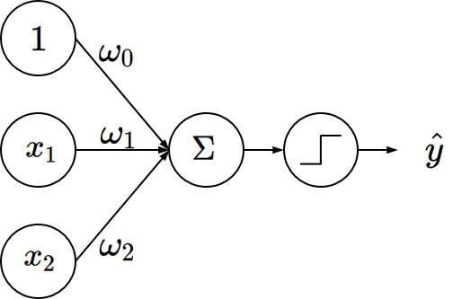

- A step function (or sign function) is non-differentiable.
  - To address this limitation, we later replace the step function with differentiable non-linear activation functions such as the sigmoid, or tanh functions.

The reason this matters is worth spelling out. The step function has zero derivative everywhere except at the origin, where the derivative does not exist. Any gradient-based learning rule therefore receives no information from it: the gradient is either zero, which says nothing about which direction to move, or undefined.

For a single perceptron this was tolerable, because the perceptron update rule was derived geometrically rather than by differentiation. For a network of many layers it is fatal. Training a deep model requires propagating derivatives backwards through every layer, and a layer whose derivative is zero blocks that flow completely. Replacing the step function with a smooth activation is therefore not a cosmetic change. It is what makes multi-layer training possible at all.

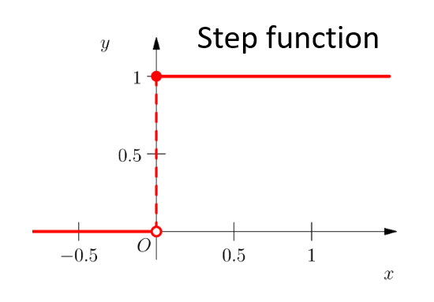

- A single layer is insufficient to solve the XOR problem.

## 2.2. Multi-Layer Perceptron (MLP) = Artificial Neural Networks (ANN)

- Multi-neurons
  - A single perceptron is often insufficient for complex tasks, as it can only learn a single hyperplane to separate the data. When the data is not linearly separable, a single hyperplane cannot capture the intricate boundaries or patterns in the feature space, necessitating deeper or more complex architectures to model the underlying relationships effectively.
  - For example, if two perceptrons are stacked, it represents two hyperplanes.

This is the whole mechanism, and it is worth stating in one sentence: a hidden layer changes the coordinates in which the problem is expressed, and the output layer solves the problem linearly in the new coordinates.

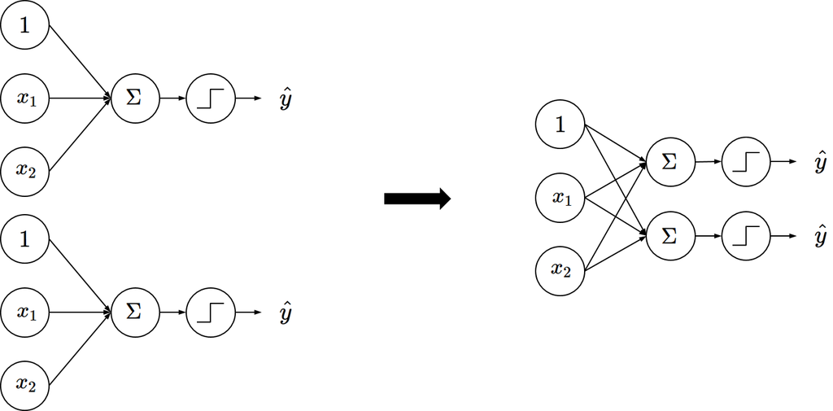

- Switch to differentiable activation function (for example, the sigmoid function)

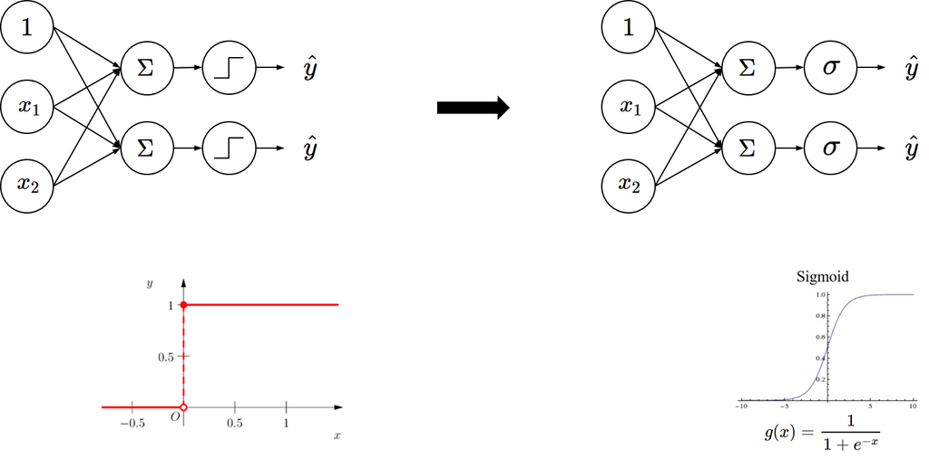

- In a compact representation
  - Combining the summation and the sigmoid function forms another neuron.

This compaction is why network diagrams are drawn as circles connected by arrows rather than as explicit formulas. A single circle stands for two operations performed in sequence: an affine combination $z = \omega^T x + b$, followed by a nonlinear activation $a = g(z)$. Both are always present, and the distinction between them will matter in Chapter 6, since backpropagation differentiates them separately.

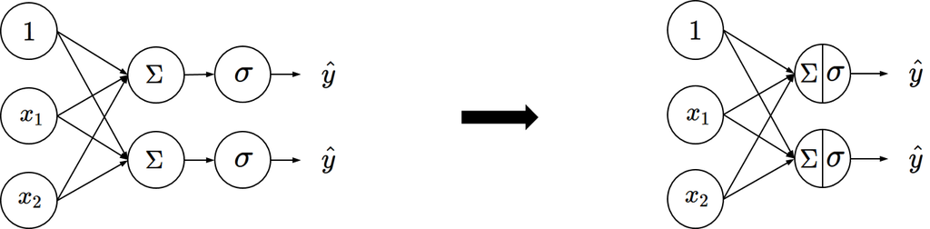

- Multi-layer perceptron
  - Can be viewed as a sequence of feature extraction layers, where each layer transforms the input into a higher-level, more abstract representation. This process of hierarchical feature extraction allows the MLP to learn complex patterns from data.

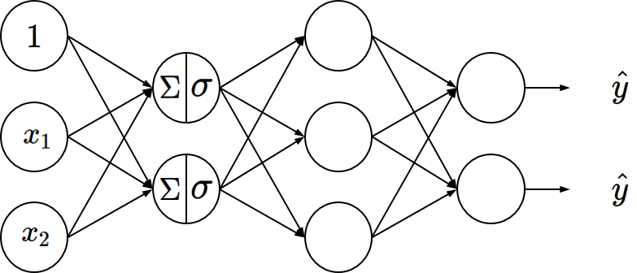

**Multi-Layer Perceptron as a Sequence of Feature Extraction**

A multi-layer perceptron is not merely a collection of neurons but a structured sequence of feature extraction steps. Each layer extracts increasingly abstract and relevant features, allowing the model to handle complex, non-linear tasks that a single-layer perceptron cannot solve.

Intuition Behind Feature Extraction in MLP

- The first layer extracts basic features from the input (e.g., edges or simple patterns in images).
- The hidden layers combine these basic features to create more complex representations (e.g., shapes, contours).
- The final layer maps the abstract features to the output (e.g., predicting a class label or regression value).

By stacking layers, the MLP gradually transforms simple input features into complex features that capture relationships in non-linear data.

Each layer can be thought of as performing a mapping from one feature space to another, progressively refining the representation to make the final decision easier.

This hierarchy of transformations allows the network to move from raw input data to task-specific representations.

**A Change in Where the Engineering Happens**

This idea deserves more emphasis than it usually receives, because it marks a genuine departure from classical modeling practice.

In traditional machine learning, a practitioner decides which features to compute from the raw data. For a vibration signal one might extract the RMS amplitude, the dominant frequency, and the kurtosis, and then fit a classifier to those three numbers. The quality of the result depends almost entirely on whether the chosen features happened to capture what mattered, and choosing them requires domain expertise that may not exist for a new problem.

A deep network removes that step. The features are parameters, and they are estimated from data by the same optimization that fits the final classifier. The engineer specifies the architecture and the objective; the network determines the representation.

The cost of this convenience should also be recognized. The learned features are optimized for the training objective and nothing else, so they carry no guarantee of physical meaning and cannot generally be interpreted. This is precisely the loss of interpretability discussed in the SciML material, and it is the reason physical constraints are introduced later to restrict what the network is allowed to learn.

## 2.3. Hidden Layers as Kernel Learning

The XOR example can be solved by pre-processing the data to make the two populations linearly separable.

The construction is small enough to carry out by hand, and doing so makes the abstract claim concrete. Add a third coordinate $x_3 = x_1 x_2$ to each of the four XOR points:

| $x_1$ | $x_2$ | $x_3 = x_1 x_2$ | $y$ |
| --- | --- | --- | --- |
| 0 | 0 | 0 | 0 |
| 0 | 1 | 0 | 1 |
| 1 | 0 | 0 | 1 |
| 1 | 1 | 1 | 0 |

In this three-dimensional space the plane $x_1 + x_2 - 2x_3 = 0.5$ separates the two classes cleanly, as may be verified by substituting the four rows. The data that was not linearly separable in two dimensions has become linearly separable in three.

Nothing about the data changed. Only its representation changed, and the boundary that appears straight in the new coordinates corresponds to a curved boundary in the original ones.

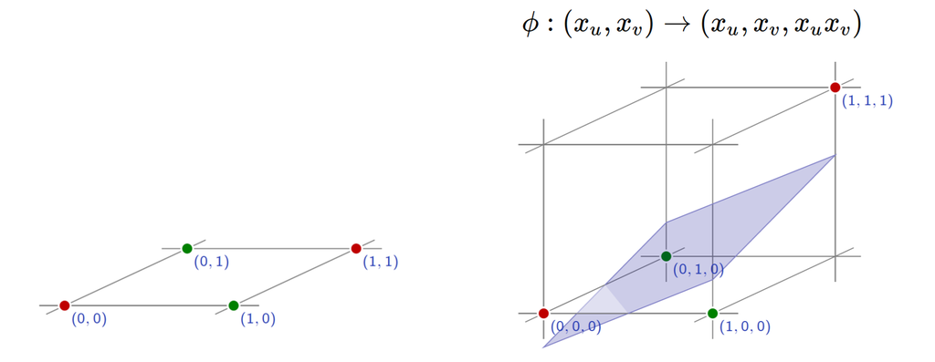

In machine learning, defining the appropriate kernels for non-linear mapping is crucial for models like support vector machines (SVMs) and kernel-based methods. However, in deep learning, the kernel function is effectively represented by the hidden layers of the neural network, which are learned directly from the data rather than being predefined.

- In traditional machine learning: Kernels (such as polynomial or RBF kernels) are manually chosen to project the input into a higher-dimensional space for better separation.
- In deep learning: The hidden layers act as adaptive feature extractors, learning the non-linear transformations (analogous to kernels) automatically during training.

This flexibility allows deep learning models, such as multi-layer perceptrons (MLPs), to discover the best representations and transformations for the data without requiring explicit kernel design.

The comparison can be made precise. Both approaches compute a prediction of the form

$$ \hat{y} = \text{(linear model)} \circ \text{(nonlinear feature map)} , $$

and they differ only in where the feature map comes from.

|  | Kernel methods | Hidden layers |
| --- | --- | --- |
| Feature map | chosen by the user in advance | learned from the data |
| Selection | requires trial, error, and domain insight | performed by gradient descent |
| Flexibility | fixed once chosen | adapts to the task |
| Interpretability | the map is known explicitly | the map is a set of learned weights |

This is why the discussion of kernel selection was left open in the previous notebook. The question of which kernel to use for a given dataset is genuinely difficult, and deep learning does not answer it. It sidesteps it, by making the feature map itself a set of parameters to be estimated. What is gained is generality; what is given up is the explicit knowledge of what transformation is being applied.

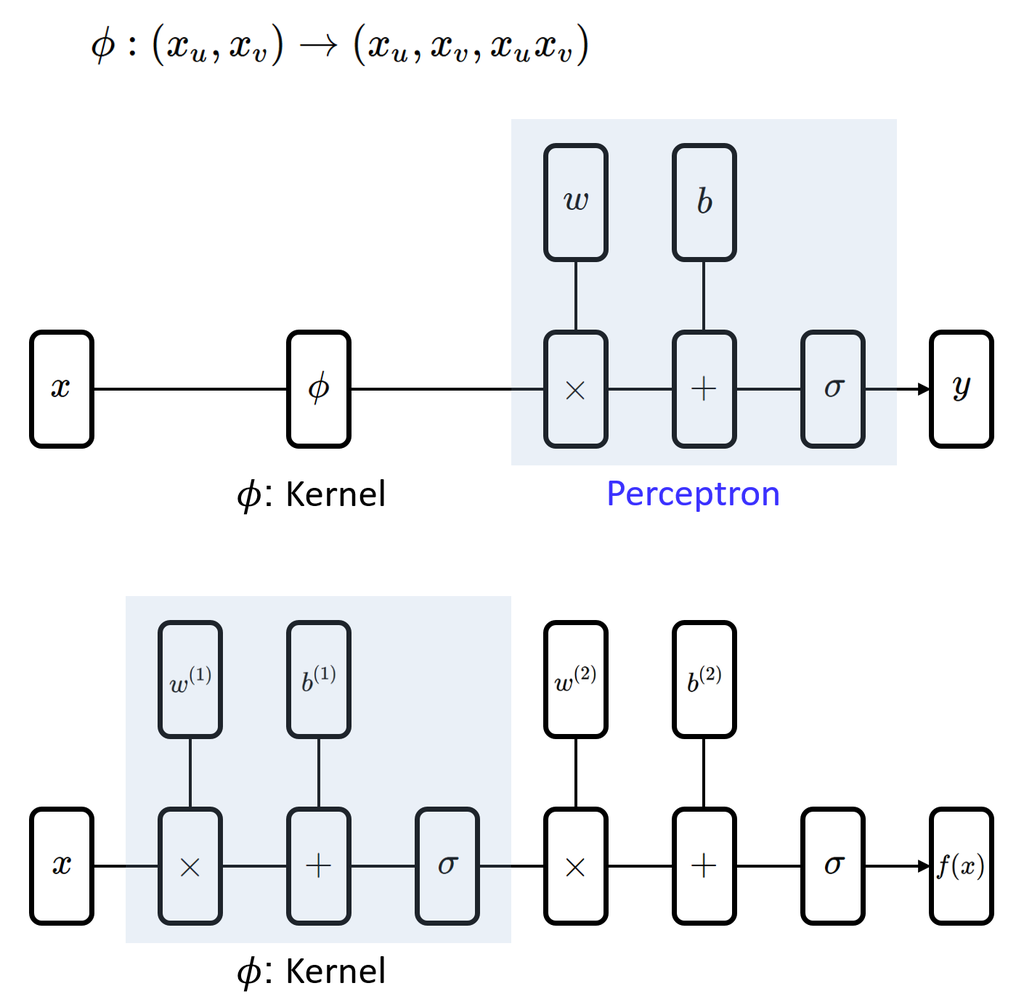

# 3. Logistic Regression in a Form of Neural Network

Here, we will demonstrate a multi-layer perceptron (MLP) using a logistic regression example. In this demonstration, we will observe the hyperplanes and the features learned in the hidden layer at the end of the training process.

- When we extend logistic regression to a multi-layer perceptron, the hidden layer transforms the input features through non-linear activations, creating intermediate feature spaces.
- At the end of learning, we can visualize how the hidden layer features and multiple hyperplanes evolve to form more complex decision boundaries.

This approach will illustrate how the MLP builds upon logistic regression by stacking multiple transformations to handle non-linear separability.

It is worth pausing on the fact that logistic regression is already a neural network. It has an input layer, no hidden layer, a single output neuron, a sigmoid activation, and a cross-entropy loss. Everything derived for it in the previous notebook therefore transfers here unchanged.

What follows adds exactly one thing to that picture: a hidden layer between the input and the output. Watching what that single addition does, on data that logistic regression alone cannot handle, is the purpose of this chapter.

Let us start with logistic regression for a linearly separable case.

$$ \begin{align*} y^{(i)} &\in \{0, 1\}\\\\ y &= \sigma (\omega_0 + \omega_1 x_1 + \omega_2 x_2) \end{align*} $$

After training, $\omega_0 + \omega_1 x_1 + \omega_2 x_2 = 0$ will represent a linear classification boundary.

```python
import numpy as np
import matplotlib.pyplot as plt
import tensorflow as tf

%matplotlib inline
```

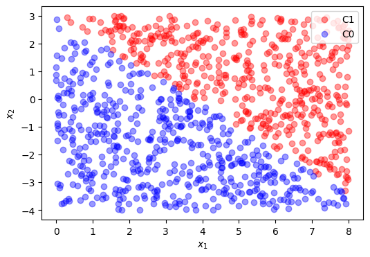

```python
#training data gerneration
m = 1000
x1 = 8*np.random.rand(m, 1)
x2 = 7*np.random.rand(m, 1) - 4

g = 0.8*x1 + x2 - 3

C1 = np.where(g >= 0)[0]
C0 = np.where(g < 0)[0]
N = C1.shape[0]
M = C0.shape[0]
m = N + M

X1 = np.hstack([x1[C1], x2[C1]])
X0 = np.hstack([x1[C0], x2[C0]])

train_X = np.vstack([X1, X0])
train_y = np.vstack([np.ones([N,1]), np.zeros([M,1])])

train_X = np.asmatrix(train_X)
train_y = np.asmatrix(train_y)

plt.figure(figsize = (6, 4))
plt.plot(x1[C1], x2[C1], 'ro', alpha = 0.4, label = 'C1')
plt.plot(x1[C0], x2[C0], 'bo', alpha = 0.4, label = 'C0')
plt.legend(loc = 1)
plt.xlabel(r'$x_1$')
plt.ylabel(r'$x_2$')
plt.show()
```

```python
LogisticRegression = tf.keras.models.Sequential([
    tf.keras.layers.Dense(input_dim = 2,
                          units = 1,
                          activation = 'sigmoid')
])
```

```python
LogisticRegression.compile(optimizer = tf.keras.optimizers.Adam(learning_rate = 0.1),
                           loss = 'binary_crossentropy')
```

```python
loss = LogisticRegression.fit(train_X, train_y, epochs = 10)
```

```python
w = LogisticRegression.layers[0].get_weights()[0]
b = LogisticRegression.layers[0].get_weights()[1]

print(w)
print("\n")
print(b)
```

```
[[1.6916244]
 [2.370146 ]]


[-6.223168]
```

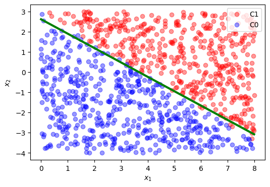

```python
x1p = np.arange(0, 8, 0.01).reshape(-1, 1)
x2p = - w[0,0]/w[1,0]*x1p - b[0]/w[1,0]

plt.figure(figsize = (6, 4))
plt.plot(x1[C1], x2[C1], 'ro', alpha = 0.4, label = 'C1')
plt.plot(x1[C0], x2[C0], 'bo', alpha = 0.4, label = 'C0')
plt.plot(x1p, x2p, 'g', linewidth = 3, label = '')
plt.xlabel('$x_1$')
plt.ylabel('$x_2$')
plt.legend(loc = 1)
plt.show()
```

## 3.1. Looking at Parameters in Nonlinear Classification

Now, let us move on to a non-linearly separable case.

In this scenario, the dataset cannot be separated by a single linear hyperplane. Therefore, we use a multi-layer perceptron (MLP), which approximates complex non-linear decision boundaries by learning multiple hyperplanes and combining them using non-linear activation functions.

Let us see how the MLP performs in this case!

Before that, let us first mention the notation changes commonly used in neural network conventions. In neural network notation, it is common to represent: $\omega_0 \rightarrow b$

- Weights as $\omega$
- Bias as $b$ (previously denoted as $\omega_0$)

$$y = \sigma(\omega_0 + \omega_1 x_1 + \omega_2 x_2) \quad \longrightarrow \quad y = \sigma(b + \omega_1 x_1 + \omega_2 x_2)$$

The change is purely notational, but it reflects a practical reality. In the previous notebook the bias was folded into the weight vector by appending an artificial coordinate $x_0 = 1$, which kept the algebra compact. In a network with many layers this becomes awkward: every layer would need its own artificial coordinate inserted and then removed. Deep learning frameworks therefore keep the bias as a separate named quantity, and every layer carries a weight matrix $W$ and a bias vector $b$ as distinct objects. The layer computation is written

$$ z = W x + b, \qquad a = g(z) . $$

This is the form in which the code below, and essentially all deep learning code, is written.

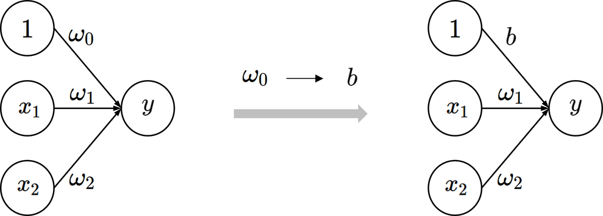

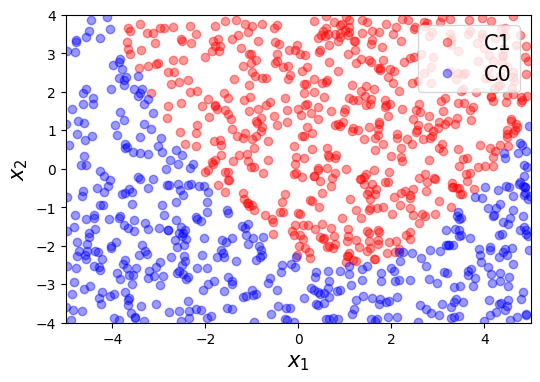

```python
# training data gerneration

m = 1000
x1 = 10*np.random.rand(m, 1) - 5
x2 = 8*np.random.rand(m, 1) - 4

g = - 0.5*(x1-1)**2 + 2*x2 + 5

C1 = np.where(g >= 0)[0]
C0 = np.where(g < 0)[0]
N = C1.shape[0]
M = C0.shape[0]
m = N + M

X1 = np.hstack([x1[C1], x2[C1]])
X0 = np.hstack([x1[C0], x2[C0]])

train_X = np.vstack([X1, X0])
train_X = np.asmatrix(train_X)

train_y = np.vstack([np.ones([N,1]), np.zeros([M,1])])

plt.figure(figsize = (6, 4))
plt.plot(x1[C1], x2[C1], 'ro', alpha = 0.4, label = 'C1')
plt.plot(x1[C0], x2[C0], 'bo', alpha = 0.4, label = 'C0')
plt.legend(loc = 1, fontsize = 15)
plt.xlabel(r'$x_1$', fontsize = 15)
plt.ylabel(r'$x_2$', fontsize = 15)
plt.xlim([-5, 5])
plt.ylim([-4, 4])
plt.show()
```

As illustrated in the figure, the data is non-linearly distributed. To approximate the non-linear decision boundary using two linear boundaries, a hidden layer with two neurons (plus a bias neuron) is intentionally added.

The word "intentionally" is important. Two hidden neurons were chosen because the boundary visible in the figure looks as though two straight cuts would suffice, and because a hidden layer of size two can be plotted directly, which makes the learned representation visible.

This is not how architectures are normally selected. In practice the number of hidden units is a hyperparameter chosen by experiment, and it is usually larger than strictly necessary. Here the smallest interesting value is chosen deliberately so that the internal state of the network can be examined rather than merely trusted.

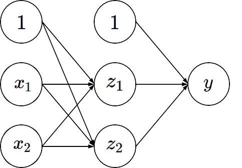

```python
LogisticRegression = tf.keras.models.Sequential([
    tf.keras.layers.Dense(input_dim = 2, units = 2, activation = 'sigmoid'),
    tf.keras.layers.Dense(units = 1, activation = 'sigmoid')
])
```

```python
LogisticRegression.compile(optimizer = tf.keras.optimizers.Adam(learning_rate = 0.1),
                           loss = 'binary_crossentropy')
```

```python
loss = LogisticRegression.fit(train_X, train_y, epochs = 10)
```

```python
w1 = LogisticRegression.layers[0].get_weights()[0]
b1 = LogisticRegression.layers[0].get_weights()[1]

w2 = LogisticRegression.layers[1].get_weights()[0]
b2 = LogisticRegression.layers[1].get_weights()[1]
```

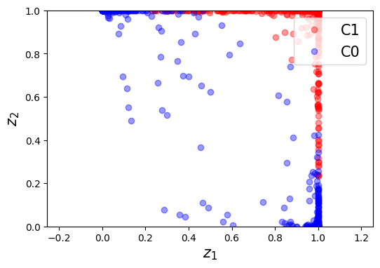

```python
H = train_X*w1 + b1
H = 1/(1 + np.exp(-H))

plt.figure(figsize = (6, 4))
plt.plot(H[0:N,0], H[0:N,1], 'ro', alpha = 0.4, label = 'C1')
plt.plot(H[N:m,0], H[N:m,1], 'bo', alpha = 0.4, label = 'C0')
plt.xlabel('$z_1$', fontsize = 15)
plt.ylabel('$z_2$', fontsize = 15)
plt.legend(loc = 1, fontsize = 15)
plt.axis('equal')
plt.xlim([0, 1])
plt.ylim([0, 1])
plt.show()
```

Here the features $z_1$ and $z_2$ learned in the hidden layer have two notable characteristics:

- Bounded Output Range: Both features are restricted to the interval $(0,1)$ due to the use of the sigmoid activation function. This non-linear transformation ensures that the outputs remain within a normalized range, regardless of the input values.
- Feature Redistribution: The hidden layer redistributes the input data into a new feature space where the transformed data becomes approximately linearly separable. This transformation allows the multi-layer perceptron to form a linear decision boundary in the higher-dimensional space that corresponds to a non-linear boundary in the original input space.

These learned features (or feature extractions) demonstrate how the hidden layer facilitates the approximation of complex patterns by creating new, informative representations of the input data.

Note what $z_1$ and $z_2$ actually are. Each hidden neuron computes $\sigma(b_j + \omega_{1j} x_1 + \omega_{2j} x_2)$, and the sigmoid argument is the signed distance from the input point to that neuron's hyperplane, up to a scale factor. The value of $z_j$ is therefore a smoothed indicator of which side of hyperplane $j$ the point lies on, close to $1$ well on one side, close to $0$ well on the other, and intermediate near the boundary itself.

The coordinates of the new representation are thus answers to the questions "which side of line 1?" and "which side of line 2?". The output layer then draws a straight boundary in the space of those two answers, which is what the next figure confirms.

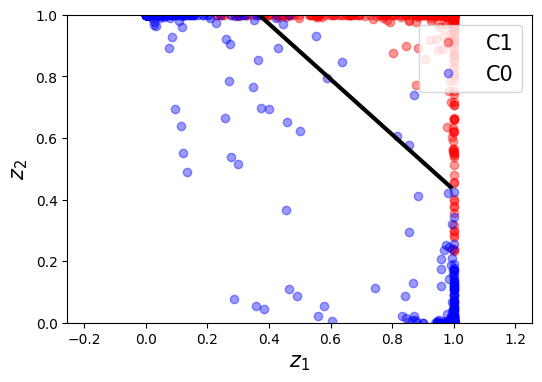

```python
x1p = np.arange(0, 1, 0.01).reshape(-1, 1)
x2p = - w2[0,0]/w2[1,0]*x1p - b2[0]/w2[1,0]

plt.figure(figsize = (6, 4))
plt.plot(H[0:N,0], H[0:N,1], 'ro', alpha = 0.4, label = 'C1')
plt.plot(H[N:m,0], H[N:m,1], 'bo', alpha = 0.4, label = 'C0')
plt.plot(x1p, x2p, 'k', linewidth = 3, label = '')
plt.xlabel('$z_1$', fontsize = 15)
plt.ylabel('$z_2$', fontsize = 15)
plt.legend(loc = 1, fontsize = 15)
plt.axis('equal')
plt.xlim([0, 1])
plt.ylim([0, 1])
plt.show()
```

The result aligns with the linear boundary in the $z$-space, indicating that the transformed features $z_1$ and $z_2$ successfully reshape the input data into a feature space where a linear decision boundary can separate the classes. This transformation validates the role of the hidden layer in projecting non-linearly distributed data into a higher-dimensional space, making it linearly separable.

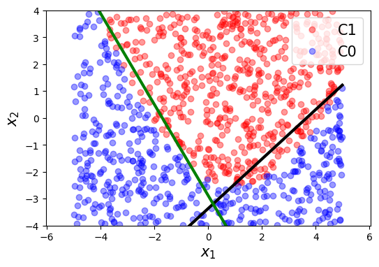

```python
x1p = np.arange(-5, 5, 0.01).reshape(-1, 1)
x2p = - w1[0,0]/w1[1,0]*x1p - b1[0]/w1[1,0]
x3p = - w1[0,1]/w1[1,1]*x1p - b1[1]/w1[1,1]

plt.figure(figsize = (6, 4))
plt.plot(x1[C1], x2[C1], 'ro', alpha = 0.4, label = 'C1')
plt.plot(x1[C0], x2[C0], 'bo', alpha = 0.4, label = 'C0')
plt.plot(x1p, x2p, 'k', linewidth = 3, label = '')
plt.plot(x1p, x3p, 'g', linewidth = 3, label = '')
plt.xlabel('$x_1$', fontsize = 15)
plt.ylabel('$x_2$', fontsize = 15)
plt.legend(loc = 1, fontsize = 15)
plt.axis('equal')
plt.xlim([-5, 5])
plt.ylim([-4, 4])
plt.show()
```

After training, two linear boundaries in the $x$-space (input space) are learned, corresponding to the linear boundaries formed by the hidden layer neurons. These boundaries result in multiple lines that, when combined, approximate the non-linear classification boundary. This demonstrates how the multi-layer perceptron (MLP) constructs a complex decision boundary in the input space by learning and integrating multiple hyperplanes from the hidden layer.

Taking the three figures together completes the argument of this chapter.

- In the input space, the hidden neurons place two straight lines. Each is an ordinary perceptron boundary, exactly as in Chapter 1.
- Passing to $z$-coordinates transforms the data so that the two classes become separable by a single straight line.
- The output neuron finds that line, which is an ordinary logistic regression in the transformed space.
- Mapping the result back to the input space produces a curved boundary, formed by combining the two straight ones.

Every individual operation is linear-plus-sigmoid, and nothing more sophisticated occurs anywhere in the network. The nonlinearity of the final boundary arises entirely from composing these simple operations. This is the essential idea of deep learning, and here it can be seen in its entirety on a single page.

# 4. Regression in a Form of Neural Network

A multi-layer perceptron (MLP) can also be applied to nonlinear regression tasks. Unlike linear regression, which fits a straight line, MLPs can model complex, nonlinear relationships between input features and the output due to their use of multiple layers and nonlinear activation functions.

In this example, the Rectified Linear Unit (ReLU) will be used as the non-linear activation function. Therefore, let us first take a closer look at ReLU before proceeding to the example.

**Rectified linear unit (ReLU activation function)**

$$h(x) = \max(0, x) = \begin{cases} 0, &\text{if}\;\; x \leq 0 \\ x, &\text{if} \;\; x > 0 \end{cases}$$

Key Characteristics of ReLU:

- Piecewise Linear: ReLU outputs zero for negative values of $x$ and passes the value of $x$ unchanged for positive values.
- Sparsity: ReLU introduces sparsity by setting some neuron activations to zero, which can make the network more efficient.
- Avoids Vanishing Gradients: Unlike sigmoid or tanh, ReLU does not squash values to a narrow range, thus avoiding the issue of vanishing gradients in deep networks.
- Non-saturating: The gradient remains constant for positive values, making optimization faster.

**Why ReLU Replaced the Sigmoid**

The sigmoid was the natural choice in Chapter 3, since its output can be read as a probability. Inside the hidden layers of a deep network, however, that interpretation is not needed, and a different property becomes decisive.

Recall that $\sigma'(z) = \sigma(z)(1 - \sigma(z))$, whose maximum value is $0.25$ and which decays toward zero for large $\lvert z \rvert$. Backpropagation multiplies one such factor for every layer it passes through, so after ten layers the gradient has been scaled by at most $0.25^{10}$, roughly $10^{-6}$. The early layers of a deep sigmoid network therefore receive almost no gradient signal and effectively stop learning. This is the vanishing gradient problem, and it is the main reason deep networks were difficult to train before the mid-2000s.

The derivative of ReLU is exactly $1$ for every positive input. Multiplying many such factors together changes nothing, so the gradient reaches the early layers intact.

**The Cost**

ReLU has a corresponding weakness that should be known. Its derivative is exactly $0$ for negative inputs, so a neuron whose pre-activation is negative for every training example receives no gradient at all and can never recover. Such a unit is said to be dead, and a network can lose a substantial fraction of its capacity this way if the learning rate is too large. Variants such as leaky ReLU, which uses a small nonzero slope for negative inputs, exist to address this.

Note also that ReLU is not differentiable at the origin. As with the perceptron loss in the previous notebook, this causes no practical difficulty, since frameworks simply assign a value there by convention.

$$h(x)$$

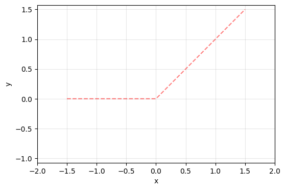

```python
import numpy as np
import tensorflow as tf
import matplotlib.pyplot as plt

def relu(x):
    return np.maximum(0, x)

xp = np.linspace(-1.5, 1.5, 100)
yp = relu(xp)

plt.figure(figsize = (6, 4))
plt.plot(xp, yp, '--', color = 'red', alpha = 0.5)
plt.xlabel('x')
plt.ylabel('y')
plt.axis('equal')
plt.xlim([-2, 2])
plt.ylim([-1.7, 2.2])
plt.grid(alpha = 0.3)
plt.show()
```

$$h(x-0.5)$$

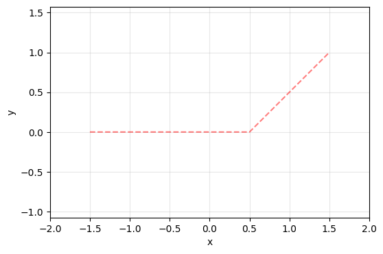

```python
xp = np.linspace(-1.5, 1.5, 100)
yp = relu(xp - 0.5)

plt.figure(figsize = (6, 4))
plt.plot(xp, yp, '--', color = 'red', alpha = 0.5)
plt.xlabel('x')
plt.ylabel('y')
plt.axis('equal')
plt.xlim([-2, 2])
plt.ylim([-1.7, 2.2])
plt.grid(alpha = 0.3)
plt.show()
```

$$h(-2x)$$

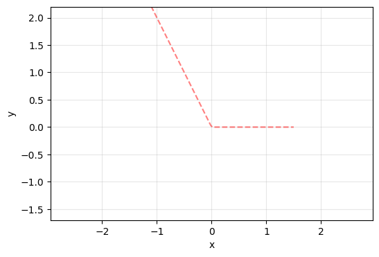

```python
xp = np.linspace(-1.5, 1.5, 100)
yp = relu(-2*xp)

plt.figure(figsize = (6, 4))
plt.plot(xp, yp, '--', color = 'red', alpha = 0.5)
plt.xlabel('x')
plt.ylabel('y')
plt.axis('equal')
plt.xlim([-2, 2])
plt.ylim([-1.7, 2.2])
plt.grid(alpha = 0.3)
plt.show()
```

$$- h(-2x-1)$$

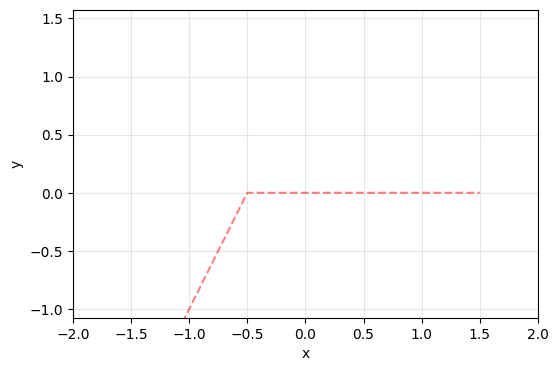

```python
xp = np.linspace(-1.5, 1.5, 100)
yp = -relu(-2*xp - 1)

plt.figure(figsize = (6, 4))
plt.plot(xp, yp, '--', color = 'red', alpha = 0.5)
plt.xlabel('x')
plt.ylabel('y')
plt.axis('equal')
plt.xlim([-2, 2])
plt.ylim([-1.7, 2.2])
plt.grid(alpha = 0.3)
plt.show()
```

The expression $\omega_2 h(\omega_1 x + b_1) + b_2 $, where $h(\cdot)$ represents the ReLU activation function, can describe a variety of transformations of the ReLU function, including horizontal and vertical shifts, as well as reflections across the $x$-axis or $y$-axis, depending on the values and signs of $\omega_1, \omega_2, b_1$, and $b_2$.

Let us consider the task of modeling a multi-layer perceptron (MLP) to approximate the given non-linear functions.

Before proceeding, it is worth confirming the claim by considering each parameter separately, since these four numbers are the entire vocabulary available to one hidden unit.

- $b_1$ shifts the kink horizontally, since the elbow occurs where $\omega_1 x + b_1 = 0$, that is, at $x = -b_1/\omega_1$.
- The sign of $\omega_1$ decides which side of the kink is flat and which side rises.
- $\omega_2$ scales the slope of the rising part, and its sign reflects the function about the horizontal axis.
- $b_2$ shifts the whole function vertically.

So a single hidden unit with ReLU produces one kink at a location it chooses, with a slope it chooses, oriented in one of four ways. The examples that follow simply ask what happens when several of these are added together.

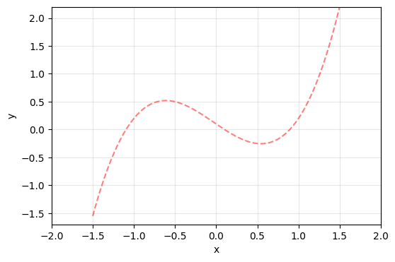

```python
import numpy as np
import tensorflow as tf
import matplotlib.pyplot as plt

np.random.seed(0)
tf.random.set_seed(0)

def function(x):
    return x**3 + 0.1*x**2 - x + 0.1

x = np.linspace(-1.5, 1.5, 1000)
y = function(x)

plt.figure(figsize = (6, 4))
plt.plot(x, y, '--', color = 'red', alpha = 0.5)
plt.xlim([-2, 2])
plt.ylim([-1.7, 2.2])
plt.xlabel('x')
plt.ylabel('y')
plt.grid(alpha = 0.3)
plt.show()
```

```python
train_x = np.random.uniform(-1.5, 1.5, 1000)
train_y = function(train_x)
```

**Nonlinear Regression as a Linear Combination of ReLU Functions**

In an MLP with ReLU activation, the output of the model can be interpreted as a linear combination of ReLU-transformed features. Each hidden layer neuron applies a ReLU transformation to a weighted sum of the input features, and the final output is a linear combination of these transformed features.

**Key Insight**:

Nonlinear regression with MLPs can be thought of as creating a piecewise linear approximation of the true function, where the linear segments are defined by the ReLU activations in the hidden layer. The network learns how to place these segments and their slopes to best fit the target function.

This picture is worth taking literally, because it makes the behavior of the network in the examples below entirely predictable.

A network with $m$ ReLU units in one hidden layer computes a function with at most $m$ kinks, and is exactly linear between consecutive kinks. Training determines two things: where the kinks are placed, through the hidden weights and biases, and what the slope change is at each kink, through the output weights. Increasing $m$ increases the number of segments available and therefore the resolution of the approximation.

The comparison with classical approximation methods is instructive. Fitting a spline requires the knots to be specified in advance, and choosing them well requires knowing where the function has structure. The network places its own knots, moving them during training toward the regions where they reduce the loss most. This is the same trade seen throughout this notebook: the user gives up explicit control and receives adaptivity in return.

It is also the intuition behind the universal approximation theorem, which states that a single hidden layer with enough units can approximate any continuous function on a bounded interval to any desired accuracy. The theorem guarantees only that such a network exists. It says nothing about how many units are required, and nothing about whether gradient descent will find the right ones.

For a neural network with one hidden layer, the predicted output $ \hat{y} $ is:

$$ \hat{y} = \sum_{j=1}^{m} \omega_j^{(2)} h\left( \sum_{i=1}^{n} \omega_{ij}^{(1)} x_i + b_j^{(1)} \right) + b^{(2)} $$

$\quad$where:

- $ \omega_{ij}^{(1)} $ and $ b_j^{(1)} $ are the weights and biases for the hidden layer.
- $ \omega_j^{(2)} $ and $ b^{(2)} $ are the weights and bias for the output layer.

In the following examples, $b^{(2)}$, the bias term for the output layer, is omitted for simplicity. In other words, the vertical shift transformation is not applied.

Read the superscripts as layer indices rather than as exponents. The quantity $\omega_{ij}^{(1)}$ is the weight connecting input $i$ to hidden unit $j$ in the first layer, and $\omega_j^{(2)}$ is the weight from hidden unit $j$ to the output in the second layer. This convention is used consistently in the code that follows and in Chapter 6.

Note the structure of the expression: the sum over $j$ is a linear combination of the hidden activations, and the nonlinearity appears only inside $h(\cdot)$. This is the same form met throughout the previous notebook, a linear model applied to a feature map, except that here the feature map contains adjustable parameters.

**Single Neuron with ReLU**

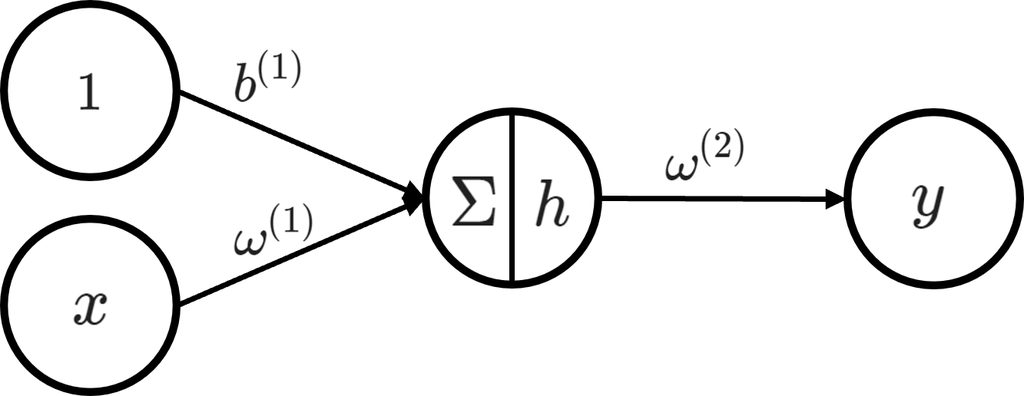

$$\hat{y} = \omega^{(2)} \left( h \left( \omega^{(1)} x + b^{(1)} \right) \right)$$

With one hidden unit the model can produce a single kink and nothing more. Whatever the target function looks like, the best this network can do is one flat portion joined to one sloped portion. Comparing the fit obtained below with the target curve shows exactly how much of the shape is out of reach, and provides the baseline against which the next two examples should be read.

```python
model = tf.keras.models.Sequential([
    tf.keras.layers.Dense(units = 1, activation = 'relu'),
    tf.keras.layers.Dense(units = 1, use_bias = False)
])
```

```python
model.compile(optimizer = 'adam',
              loss = 'mse')
```

```python
train_x = train_x.reshape(-1, 1)
train_y = train_y.reshape(-1, 1)

model.fit(train_x, train_y, epochs = 500, verbose = 0)
```

```
<keras.src.callbacks.History at 0x7cb22461d150>
```

```python
weights = model.layers[0].get_weights()[0]
biases = model.layers[0].get_weights()[1]
weights2 = model.layers[1].get_weights()[0]

print("Coefficients (Weights):", weights)
print("Intercepts (Biases):", biases)
print("Coefficients (Weights):", weights2)
```

```
Coefficients (Weights): [[-0.4981401]]
Intercepts (Biases): [-0.7469519]
Coefficients (Weights): [[1.1054615]]
```

```python
real_x = np.linspace(-1.5, 1.5, 100)
real_y = function(real_x)
```

```python
def relu(x):
    return np.maximum(0, x)
```

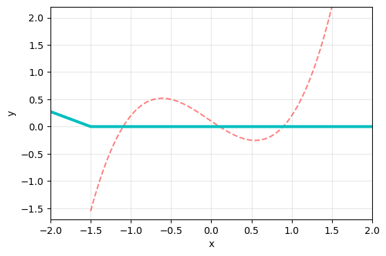

```python
x1p = np.arange(-2, 2, 0.01).reshape(-1, 1)
x2p = weights2*(relu(weights*x1p + biases))

plt.figure(figsize = (6, 4))
plt.xlim([-2, 2])
plt.ylim([-1.7, 2.2])
plt.plot(real_x, real_y, '--', color = 'red', alpha = 0.5)
plt.plot(x1p, x2p, 'c', linewidth = 3)
plt.xlabel('x')
plt.ylabel('y')
plt.grid(alpha = 0.3)
plt.show()
```

**Two Neurons with ReLU**

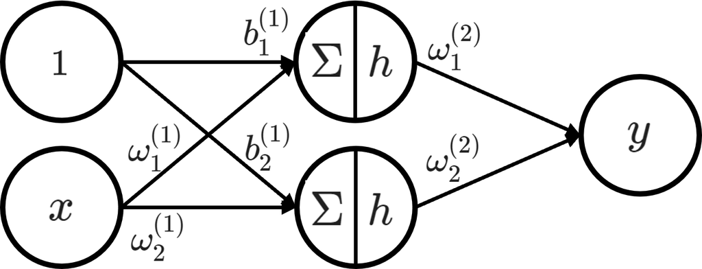

$$\hat{y} = \omega_1^{(2)} \left( h \left( \omega_1^{(1)} x + b_1^{(1)} \right) \right) + \omega_2^{(2)} \left( h \left( \omega_2^{(1)} x + b_2^{(1)} \right) \right)$$